# Assignment 3

Emorie D Beck

10/11/2017

# Workspace

## Packages

```r
library(psych)
library(sjPlot)
library(broom)
library(lme4)
library(MuMIn)
library(merTools)
library(reghelper)
library(stargazer)
library(lsmeans)
library(multcompView)
library(plyr)
library(tidyverse)
```

# Background

## Sample Data

The National Longitudinal Study of Youths 1979 Child and Young Adult Sample (NLSYCYA) is a longitudinal study conducted by the National Bureau of Labor Statistics. The sample includes the children of the original 1979 sample. Here, we are going to use a subset of the more than 11,000 variables available that include the following.

| Item Name | Description | Time-Varying? |
| --- | --- | --- |
| PROC_CID | Participant ID | No |
| Dem_DOB | Year of Date of Birth | No |
| groups | Jail, Community Service, None | No |
| DemPWeight | Weight Percentile at age 10 | No |
| age | Age of participant | Yes |
| Year | Year of Survey | Yes |
| age0 | Age of participant (centered) | Yes |
| SensSeek | Sensation-Seeking Composite | Yes |
| CESD | CESD Depression Composite | Yes |

```r
data_path <- "https://github.com/longitudinal-data/1-descriptives-and-graphs-emoriebeck/raw/master/Conditional_Models"
load(url(paste(data_path, "sample.RData", sep = "/")))

head(sample_dat)
```

```
## # A tibble: 6 x 8
##   PROC_CID   age  year  age0   groups      CESD SensSeek DemPweight
##      <dbl> <dbl> <dbl> <dbl>   <fctr>     <dbl>    <dbl>      <dbl>
## 1     1601    16  2006     2 CommServ 0.4285714 3.666667  0.8159399
## 2     1601    18  2008     4 CommServ 2.0000000 3.000000  0.8159399
## 3     9102    16  2012     2     None 0.1818182 3.333333  0.6712397
## 4     9501    14  2000     0     Jail 0.5000000 3.000000  0.5477584
## 5     9501    18  2004     4     Jail 0.4285714 3.000000  0.5477584
## 6     9501    22  2008     8     Jail 0.4285714 3.000000  0.5477584
```

# Time Invariant Predictors

## Time Invariant Predictors: Continuous

But we need to break this down to see that adding additional predictors results in interaction terms:

$Y_{ij} = \gamma_{00} + \gamma_{01}*X_{2j} + U_{0j} + (\gamma_{10} + \gamma_{11}*X_{2j} + U_{1j})*X_{1j} + \varepsilon{ij}$ $Y_{ij} = \gamma_{00} + \gamma_{01}*X_{2j} + \gamma_{10}*X_{1j} + \textcolor{red}{\gamma_{11}*X_{2j}*X_{1j}} + U_{0j} + U_{1j}*X_{1j} + \varepsilon{ij}$

We can also fit this with intercepts depending on weight, but without the change (slope) dependent on weight:  
$Y_{ij} = \gamma_{00} + \gamma_{01}*X_{2j} + U_{0j} + (\gamma_{10} + U_{1j})*X_{1j} + \varepsilon{ij}$ $Y_{ij} = \gamma_{00} + \gamma_{01}*X_{2j} + \gamma_{10}*X_{1j} + U_{0j} + U_{1j}*X_{1j} + \varepsilon{ij}$

### Continuous Example - Weight for Age Percentile

```r
describe(sample_dat$DemPweight)
```

```
##    vars    n mean   sd median trimmed  mad   min  max range  skew kurtosis
## X1    1 2084 0.66 0.31   0.69    0.67 0.36 -0.06 1.62  1.68 -0.29    -0.56
##      se
## X1 0.01
```

```r
# time invariant covariate with random intecept (with weight as covariate)
# and slope (without weight as a covariate)
mod1a <- lmer(SensSeek ~ age0 + DemPweight + (age0|PROC_CID),
              data = sample_dat)

summary(mod1a)

# time invariant predictor with random slope and intercept
mod1b <- lmer(SensSeek ~ age0 + DemPweight + age0*DemPweight +
                (age0|PROC_CID), data = sample_dat)

summary(mod1b)
```

[output not shown]

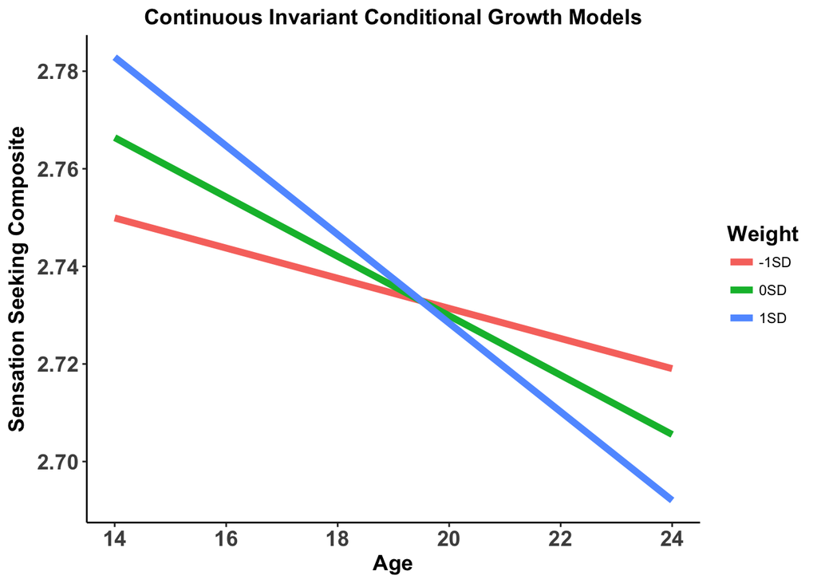

```r
fixed.frame <- sample_dat %>%
  summarise(mean = mean(DemPweight, na.rm = T),
            sd = sd(DemPweight, na.rm = T))

fixed.frame <-
  data.frame(
    expand.grid(
      # here, you add values for your time variable and predictors
      age0 = seq(0,10,2),
      DemPweight = c(fixed.frame$mean-fixed.frame$sd,
                     fixed.frame$mean,
                     fixed.frame$mean+fixed.frame$sd))) %>%
  mutate(pred = predict(mod1b, newdata = ., re.form = NA))


fixed.frame %>%
  mutate(Weight = factor(DemPweight, levels = unique(DemPweight), labels = c("-1SD", "0SD", "1SD")),
         age = age0 + 14) %>%
  ggplot(aes(x = age, y = pred, color = Weight)) +
    geom_line(size = 2) +
    labs(x = "Age", y = "Sensation Seeking Composite",
         title = "Continuous Invariant Conditional Growth Models") +
    theme_classic() +
    theme(axis.text = element_text(face = "bold", size = rel(1.2)),
          axis.title = element_text(face = "bold", size = rel(1.2)),
          legend.title = element_text(face = "bold", size = rel(1.2)),
          plot.title = element_text(face = "bold", size = rel(1.2), hjust = .5))
```

## Time Invariant Predictors: Categorical

### Categorical Example - 2 level group

[output not shown]

And model it:

```r
mod2ga <- lmer(SensSeek ~ age0 + groups + (age0|PROC_CID),
              data = sample_dat %>% filter(groups != "CommServ"))
mod2g <- lmer(SensSeek ~ age0 + groups + age0*groups + (age0|PROC_CID),
              data = sample_dat %>% filter(groups != "CommServ"))
summary(mod2g)
```

```
## Linear mixed model fit by REML ['lmerMod']
## Formula: SensSeek ~ age0 + groups + age0 * groups + (age0 | PROC_CID)
##    Data: sample_dat %>% filter(groups != "CommServ")
##
## REML criterion at convergence: 2607.6
##
## Scaled residuals:
##     Min      1Q  Median      3Q     Max
## -3.2324 -0.4860  0.0463  0.4643  3.0578
##
## Random effects:
##  Groups   Name        Variance  Std.Dev. Corr
##  PROC_CID (Intercept) 0.1613721 0.40171
##           age0        0.0008963 0.02994  -0.31
##  Residual             0.1897644 0.43562
## Number of obs: 1573, groups:  PROC_CID, 689
##
## Fixed effects:
##                  Estimate Std. Error t value
## (Intercept)      2.717417   0.036423   74.61
## age0            -0.003998   0.006382   -0.63
## groupsJail       0.093497   0.048257    1.94
## age0:groupsJail -0.007432   0.008272   -0.90
##
## Correlation of Fixed Effects:
##             (Intr) age0   grpsJl
## age0        -0.624
## groupsJail  -0.755  0.471
## age0:grpsJl  0.481 -0.772 -0.623
```

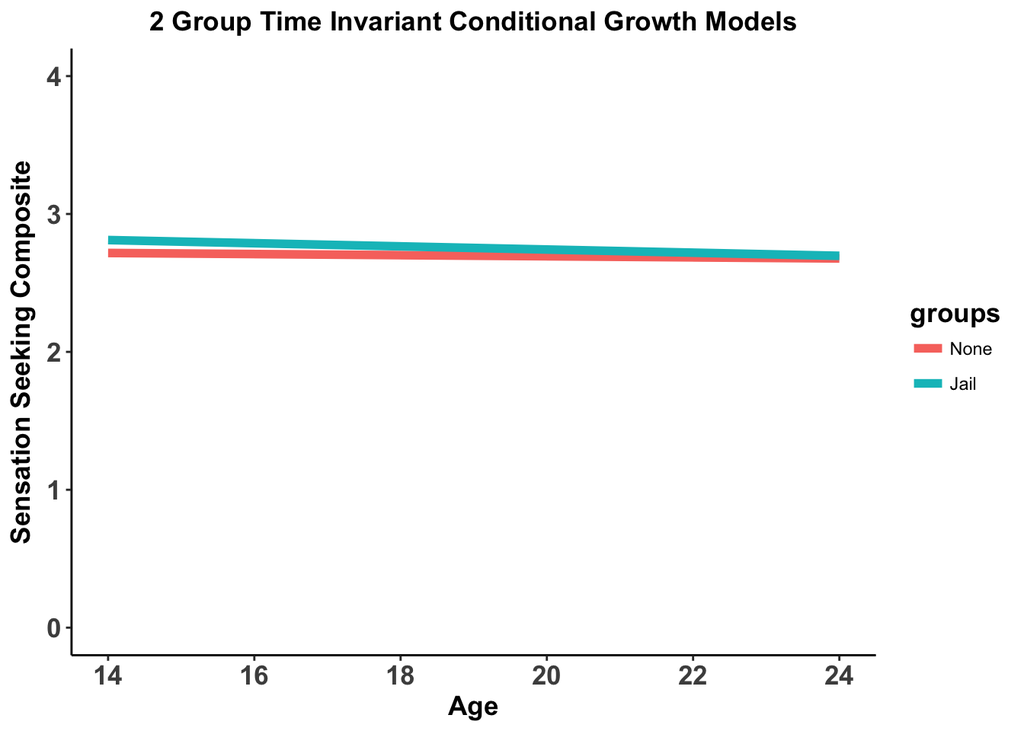

```r
fixed.frame <-
  data.frame(expand.grid(age0 = seq(0,10,2),
             groups = c("None","Jail"))) %>%
  mutate(pred = predict(mod2g, newdata = ., re.form = NA))

fixed.frame %>%
  mutate(age = age0 + 14) %>%
  ggplot(aes(x = age, y = pred, color = groups)) +
    geom_line(size = 2) +
    lims(y = c(0,4)) +
    labs(x = "Age", y = "Sensation Seeking Composite",
         title = "2 Group Time Invariant Conditional Growth Models") +
    theme_classic() +
    theme(axis.text = element_text(face = "bold", size = rel(1.2)),
          axis.title = element_text(face = "bold", size = rel(1.2)),
          legend.title = element_text(face = "bold", size = rel(1.2)),
          plot.title = element_text(face = "bold", size = rel(1.2), hjust = .5))
```

## Both Continuous and Categorical

```r
mod3 <- lmer(SensSeek ~ age0*groups + age0*DemPweight + (age0|PROC_CID), data = sample_dat)
```

# Time Varying Predictors

## Time Varying Predictors: Continuous

Next, we’ll add in a time-varying predictor. Maybe it’s not that our participants sensation seeking is moderated by early life experiences of jail or court-ordered community service. Instead, their sensation seeking is moderated by depression.  
How does this look?

### To Interaction or Not - That Is the Question

$$Y_{ij} = \gamma_{00} + \gamma_{01} + U_{0j} + (\gamma_{10} + U_{1j})*age0 + \gamma_{20}*CESD$$

### Example: Does depression influence changes in sensation seeking over time?

```r
modTV1 <- lmer(SensSeek ~ age0 + CESD + (age0|PROC_CID), data = sample_dat)
```

```r
summary(modTV1)
```

```
## Linear mixed model fit by REML ['lmerMod']
## Formula: SensSeek ~ age0 + CESD + (age0 | PROC_CID)
##    Data: sample_dat
##
## REML criterion at convergence: 3391.9
##
## Scaled residuals:
##     Min      1Q  Median      3Q     Max
## -3.4390 -0.5035  0.0363  0.4423  3.1508
##
## Random effects:
##  Groups   Name        Variance  Std.Dev. Corr
##  PROC_CID (Intercept) 0.1412384 0.37582
##           age0        0.0008117 0.02849  -0.21
##  Residual             0.1892166 0.43499
## Number of obs: 2084, groups:  PROC_CID, 924
##
## Fixed effects:
##              Estimate Std. Error t value
## (Intercept)  2.710845   0.025121  107.91
## age0        -0.006475   0.003553   -1.82
## CESD         0.078617   0.021519    3.65
##
## Correlation of Fixed Effects:
##      (Intr) age0
## age0 -0.467
## CESD -0.604 -0.036
```

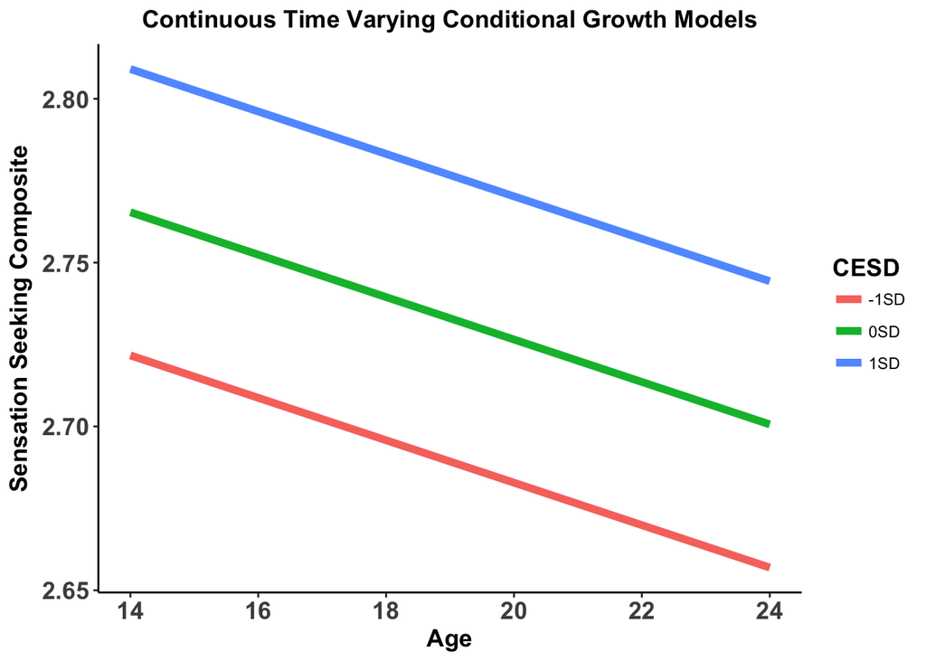

```r
# example for continuous
# note MEANS ARE AT AGE0 = 0
fixed.frame <- sample_dat %>%
  filter(age0 == 0) %>%
  summarise(mean = mean(CESD, na.rm = T),
            sd = sd(CESD, na.rm = T))

fixed.frame <-
  data.frame(
    expand.grid(
      # here, you add values for your time variable and predictors
      age0 = seq(0,10,2),
      CESD = c(fixed.frame$mean-fixed.frame$sd,
                     fixed.frame$mean,
                     fixed.frame$mean+fixed.frame$sd))) %>%
  mutate(pred = predict(modTV1, newdata = ., re.form = NA))

fixed.frame %>%
  mutate(CESD = factor(CESD, levels = unique(CESD), labels = c("-1SD", "0SD", "1SD")),
         age = age0 + 14) %>%
  ggplot(aes(x = age, y = pred, color = CESD)) +
    geom_line(size = 2) +
    labs(x = "Age", y = "Sensation Seeking Composite",
         title = "Continuous Time Varying Conditional Growth Models") +
    theme_classic() +
    theme(axis.text = element_text(face = "bold", size = rel(1.2)),
          axis.title = element_text(face = "bold", size = rel(1.2)),
          legend.title = element_text(face = "bold", size = rel(1.2)),
          plot.title = element_text(face = "bold", size = rel(1.2), hjust = .5))
```

## Time Varying Predictors: Categorical

Next, we’ll add in a time-varying predictor. Maybe it’s not that our participants sensation seeking is moderated by early life experiences of jail or court-ordered community service. Instead, their sensation seeking is moderated by depression.  
How does this look?

```r
# creating a dummy variable for time varying categorical depression
sample_dat <- sample_dat %>%
  mutate(depressed =
           factor(ifelse(CESD <= 1.5, 0, 1), levels = c(0,1),
                  labels = c("Depressed", "Not Depressed")))
modTV2 <- lmer(SensSeek ~ age0 + depressed + (age0|PROC_CID),
               data = sample_dat)
summary(modTV2)
```

```
## Linear mixed model fit by REML ['lmerMod']
## Formula: SensSeek ~ age0 + depressed + (age0 | PROC_CID)
##    Data: sample_dat
##
## REML criterion at convergence: 3401
##
## Scaled residuals:
##     Min      1Q  Median      3Q     Max
## -3.3686 -0.5094  0.0363  0.4522  3.1406
##
## Random effects:
##  Groups   Name        Variance  Std.Dev. Corr
##  PROC_CID (Intercept) 0.1427348 0.37780
##           age0        0.0008415 0.02901  -0.21
##  Residual             0.1895333 0.43535
## Number of obs: 2084, groups:  PROC_CID, 924
##
## Fixed effects:
##                         Estimate Std. Error t value
## (Intercept)             2.760189   0.020388  135.38
## age0                   -0.006154   0.003564   -1.73
## depressedNot Depressed  0.068617   0.039992    1.72
##
## Correlation of Fixed Effects:
##             (Intr) age0
## age0        -0.599
## dprssdNtDpr -0.174 -0.024
```

[figure not shown]

```r
fixed.frame <-
  data.frame(expand.grid(age0 = seq(0,10,2),
             depressed = c("Depressed","Not Depressed"))) %>%
  mutate(pred = predict(modTV2, newdata = ., re.form = NA))

fixed.frame %>%
  mutate(age = age0 + 14) %>%
  ggplot(aes(x = age, y = pred, color = depressed)) +
    geom_line(size = 2) +
    lims(y = c(0,4)) +
    labs(x = "Age", y = "Sensation Seeking Composite",
         title = "2 Group Time Invariant Conditional Growth Models") +
    theme_classic() +
    theme(axis.text = element_text(face = "bold", size = rel(1.2)),
          axis.title = element_text(face = "bold", size = rel(1.2)),
          legend.title = element_text(face = "bold", size = rel(1.2)),
          plot.title = element_text(face = "bold", size = rel(1.2), hjust = .5))
```